# Nora Master Project Data Analysis Notebook

Nora Luo

# Table of Contents

1. Notation
2. Load and split the data
3. Screening Questions
4. Actual Survey Analysis
5. Statistical Testing
6. Skewed Data
7. Decision-making

# README

- run the Load and split the data chunk first
- results was filtered based on Q3.9 - whether respondents understand the concept of inflation
- ! : We reject the null hypothesis.

# Load and split the data

```r
library(readr)
library(dplyr)
```

```r
library(ggplot2)
library(tidyr)
library(FSA)
library(car)
library(rstatix)
library(effectsize)
exported_data <- read_csv("final_rawdata_value_1605.csv")
exported_data <- subset(exported_data, select = -c(StartDate,EndDate,Status,IPAddress,Progress,Finished,RecordedDate, RecipientLastName,RecipientFirstName,                                  RecipientEmail,ExternalReference,LocationLatitude,LocationLongitude,DistributionChannel,UserLanguage))
rawdata_value <- subset(exported_data, select =-c(ResponseId,Q1.1,Q2.1))
rawdata_value <- rawdata_value[3:nrow(rawdata_value), ]

# label the group
rawdata_value <- rawdata_value %>%
  mutate(group = case_when(
    !is.na(Q4.2)  ~ '0-controlled',
    !is.na(Q6.2)  ~ '1-errorbar',
    !is.na(Q8.2)  ~ '2-shadedbar',
    !is.na(Q10.2) ~ '3-fanchartslice',
    !is.na(Q12.2) ~ '4-bellcurve'
  ),
  treatment = case_when(
    group %in% c("1-errorbar","2-shadedbar","3-fanchartslice","4-bellcurve")
      ~ "treatment_group",
     TRUE
      ~ as.character(group)     # or another fallback
  ))
# create a copy of the data for Q3.9 analysis
rawdata_q3_9 <- rawdata_value
# filter participants who do not understand the concept of inflation
rawdata_value <- rawdata_value[rawdata_value$Q3.9 == "4", ]

# rawdata_value <- rawdata_value %>%
#   mutate(group = case_when(
#     !is.na(Q4.2)  ~ 0,
#     !is.na(Q6.2)  ~ 1,
#     !is.na(Q8.2)  ~ 2,
#     !is.na(Q10.2) ~ 3,
#     !is.na(Q12.2) ~ 4
#   ))

# meta-data
total_respondents <- nrow(rawdata_value)


group_total <- rawdata_value %>%
  group_by(group) %>%
  summarise(n_respondents = n())

total_treatment_respodents <- total_respondents - group_total$n_respondents[1]


# graph preparation

likelihood_labels = c(
    "9" = "Exceptionally unlikely",
    "10" = "Very unlikely",
    "11" = "Quite unlikely",
    "12" = "Fifty-fifty",
    "13" = "Quite likely",
    "14" = "Very likely",
    "15" = "Virtually certain"
  )

# filter treatment groups
controlled_group <- rawdata_value[!is.na(rawdata_value$Q4.2), ]
error_bar <-rawdata_value[!is.na(rawdata_value$Q6.2), ]
shaded_bar <-rawdata_value[!is.na(rawdata_value$Q8.2), ]
fanchart_slice <-rawdata_value[!is.na(rawdata_value$Q10.2), ]
bell_curve <-rawdata_value[!is.na(rawdata_value$Q12.2), ]

# adding labels to the groups
# controlled_group$group <- 1
# error_bar$group <- 2
# shaded_bar$group <- 3
# fanchart_slice$group <- 4
# bell_curve$group <- 5


# remove unnecessary columns
controlled_group = controlled_group[,grepl("^(Q3|Q4|Q5)",names(controlled_group))|names(controlled_group) %in% c("Duration (in seconds)", "group","treatment")]
error_bar = error_bar[,grepl("^(Q3|Q6|Q7)",names(error_bar))| names(error_bar) %in% c("Duration (in seconds)", "group","treatment")]
shaded_bar = shaded_bar[,grepl("^(Q3|Q8|Q9)",names(shaded_bar))| names(shaded_bar)%in% c("Duration (in seconds)", "group","treatment")]
fanchart_slice = fanchart_slice[,grepl("^(Q3|Q10|Q11)",names(fanchart_slice))| names(fanchart_slice) %in% c("Duration (in seconds)", "group","treatment")]
bell_curve = bell_curve[,grepl("^(Q3|Q12|Q13)",names(bell_curve))| names(bell_curve) %in% c("Duration (in seconds)", "group","treatment")]
# controlled_group = controlled_group[,!sapply(controlled_group, function(x) mean(is.na(x)))>0.9]

group_list <- list(
  controlled = controlled_group,
  errorbar = error_bar,
  shadedbar = shaded_bar,
  fanchartslice = fanchart_slice,
  bellcurve = bell_curve
)

skewed_group_list <- group_list[-1]
```

# Screening Questions

## ! Time Duration

```r
time_duration_table <- rawdata_value[,c("Duration (in seconds)", "group")]
time_duration_table$`Duration (in mins)` <- as.numeric(time_duration_table$`Duration (in seconds)`)/60

# report quantile information
summary(time_duration_table$`Duration (in mins)`)
```

```
##    Min. 1st Qu.  Median    Mean 3rd Qu.    Max.
##   4.117  14.233  19.817  22.397  27.133  69.617
```

```r
# test for normality --> It's definitely not normal distribution
# shapiro.test(time_duration_table$`Duration (in mins)`)

# run the kruskal-wallis test
kruskal_test <- kruskal.test(`Duration (in mins)` ~ group, data = time_duration_table)
print(kruskal_test)
```

```
##
##  Kruskal-Wallis rank sum test
##
## data:  Duration (in mins) by group
## Kruskal-Wallis chi-squared = 30.533, df = 4, p-value = 3.811e-06
```

```r
# run post-hoc test
dunn_test <- dunnTest(`Duration (in mins)` ~ group, data = time_duration_table, method = "bonferroni")
print(dunn_test)
```

```
## Dunn (1964) Kruskal-Wallis multiple comparison
```

```
##   p-values adjusted with the Bonferroni method.
```

```
##                        Comparison          Z      P.unadj        P.adj
## 1       0-controlled - 1-errorbar -3.5097005 4.486117e-04 4.486117e-03
## 2      0-controlled - 2-shadedbar -4.5684263 4.913997e-06 4.913997e-05
## 3        1-errorbar - 2-shadedbar -1.0161356 3.095648e-01 1.000000e+00
## 4  0-controlled - 3-fanchartslice -4.9558935 7.199866e-07 7.199866e-06
## 5    1-errorbar - 3-fanchartslice -1.3294386 1.837033e-01 1.000000e+00
## 6   2-shadedbar - 3-fanchartslice -0.2964099 7.669170e-01 1.000000e+00
## 7      0-controlled - 4-bellcurve -3.0646454 2.179282e-03 2.179282e-02
## 8        1-errorbar - 4-bellcurve  0.4690361 6.390438e-01 1.000000e+00
## 9       2-shadedbar - 4-bellcurve  1.4977050 1.342099e-01 1.000000e+00
## 10  3-fanchartslice - 4-bellcurve  1.8233127 6.825604e-02 6.825604e-01
```

Time duration summary table

```r
time_duration_summary <- time_duration_table %>%
  group_by(group) %>%
  summarise(mean_duration = mean(`Duration (in mins)`, na.rm = TRUE),
            sd_duration = sd(`Duration (in mins)`, na.rm = TRUE),
            .groups = 'drop')
```

Plot the distribution of different groups

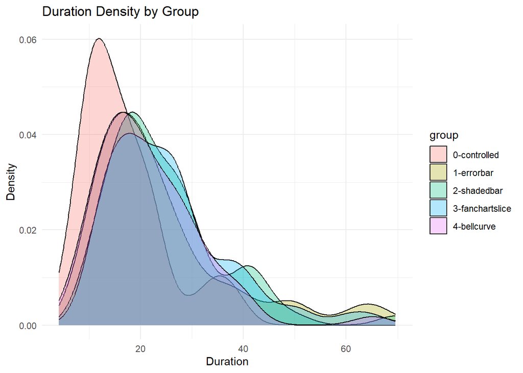

```r
# density plot
ggplot(time_duration_table, aes(x = `Duration (in mins)`, fill = group)) +
  geom_density(alpha = 0.3) +
  # facet_wrap(~ group, scales = "free") +
  labs(title = "Duration Density by Group",
       x = "Duration",
       y = "Density") +
  theme_minimal()
```

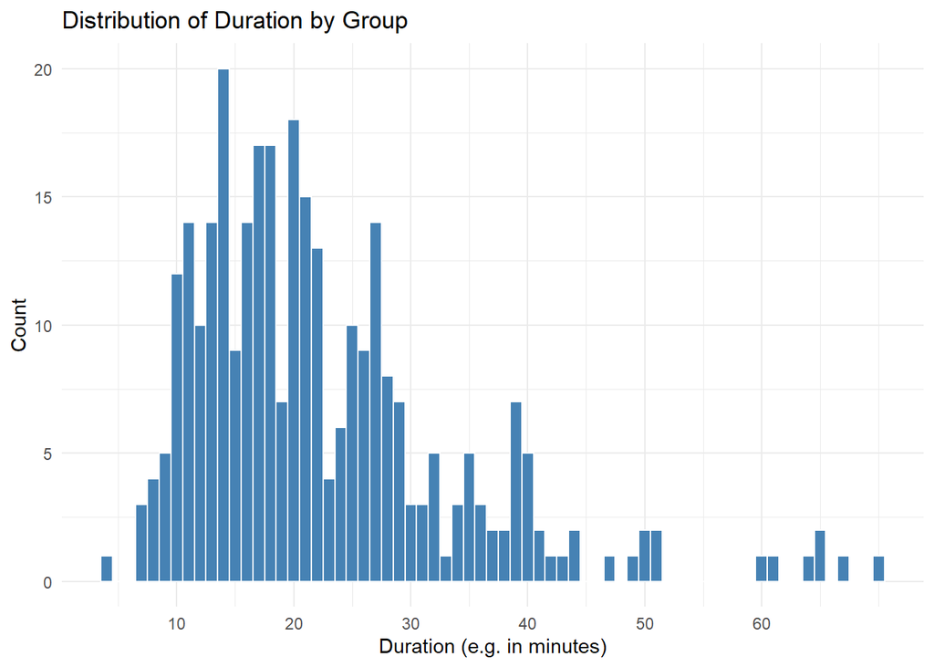

```r
# histogram
ggplot(time_duration_table, aes(x = `Duration (in mins)`)) +
  geom_histogram(binwidth = 1, fill = "steelblue", color = "white") +
  # facet_wrap(~ group) +
  labs(title = "Distribution of Duration by Group",
       x = "Duration (e.g. in minutes)",
       y = "Count") +
  scale_x_continuous(breaks = seq(0, max(time_duration_table$`Duration (in mins)`, na.rm = TRUE), by = 10)) +
  theme_minimal()
```

Plot time duration bar chart. It’s not valid as the data is not normal distribution.

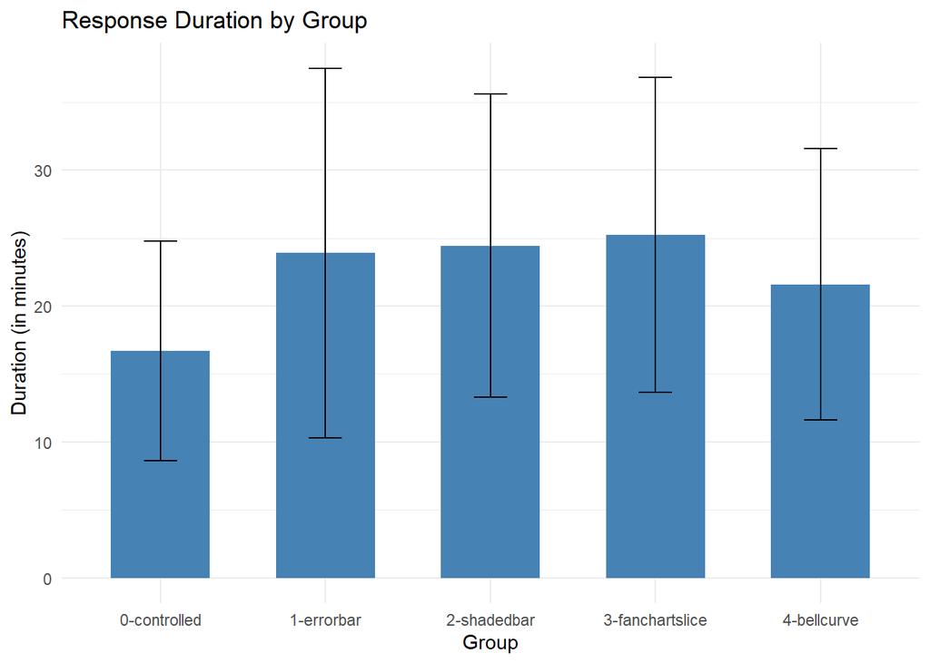

```r
ggplot(time_duration_summary, aes(x = group, y = mean_duration)) +
  geom_bar(stat = "identity", fill = "steelblue", width = 0.6) +
  geom_errorbar(aes(ymin = mean_duration - sd_duration, ymax = mean_duration + sd_duration), width = 0.2) +
  labs(title = "Response Duration by Group",
       y = "Duration (in minutes)",
       x = "Group") +
  theme_minimal()
```

## Q3.2 Age

What is your age?  
Variable: continuous  
Method: kruskal-wallis test  
**Result: Fail to reject the null hypothesis**

```r
age_table <- rawdata_value[, c("Q3.2", "group")]
age_table$`Q3.2` <- as.numeric(gsub("[^0-9.]", "", age_table$`Q3.2`))

# test for normality
# shapiro.test(age_table$`Q3.2`)
# bartlett.test(`Q3.2` ~ group, data = age_table)


# run the kruskal-wallis test
kruskal_test <- kruskal.test(`Q3.2` ~ group, data = age_table)
print(kruskal_test)
```

```
##
##  Kruskal-Wallis rank sum test
##
## data:  Q3.2 by group
## Kruskal-Wallis chi-squared = 3.0501, df = 4, p-value = 0.5495
```

```r
age_summary <- age_table %>%
  group_by(group) %>%
  summarise(mean_age = mean(`Q3.2`, na.rm = TRUE),
            sd_age = sd(`Q3.2`, na.rm = TRUE),
            .groups = 'drop')
```

## Q3.3 Gender

Which of the following best describes your gender identity?  
Variable: categorical  
Method: contingency Table + chi-squared test  
**Result: Fail to reject the null hypothesis**

```r
q3_3_table <- rawdata_value[, c("Q3.3", "group")]
# q3_3_table$Q3.3 <- recode(q3_3_table$Q3.3,
#                                     "1" = "Male",
#                                     "2" = "Female",
#                                     .default = "Other")
q3_3_contingency <- table(q3_3_table$Q3.3, q3_3_table$group)
print(q3_3_contingency)
```

```
##
##     0-controlled 1-errorbar 2-shadedbar 3-fanchartslice 4-bellcurve
##   1           34         28          29              35          28
##   2           28         29          31              31          33
##   3            0          1           1               0           0
##   4            0          1           0               0           0
```

```r
# Chi-squared test
chisq.test(q3_3_contingency)
```

```
##
##  Pearson's Chi-squared test
##
## data:  q3_3_contingency
## X-squared = 8.7585, df = 12, p-value = 0.7234
```

Calculate the gender percentage

```r
# percentage of male
male_per <- q3_3_contingency[1,]
gender_group_total <- colSums(q3_3_contingency)
male_prop <- male_per/gender_group_total
```

## Q3.4 Highest Education

What is your highest level of education achieved?  
Variable: categorical with written insights from choice 9 Method: contingency Table + chi-squared test  
**Result: Fail to reject the null hypothesis**

```r
q3_4_table <- rawdata_value[rawdata_value$`Q3.4` != "9", c("Q3.4", "group")]

q3_4_contingency <- table(q3_4_table$Q3.4, q3_4_table$group)
# Chi-squared test
chisq.test(q3_4_contingency)
```

```
##
##  Pearson's Chi-squared test
##
## data:  q3_4_contingency
## X-squared = 18.836, df = 28, p-value = 0.9031
```

Highest Education Level proportion bar plot across different groups

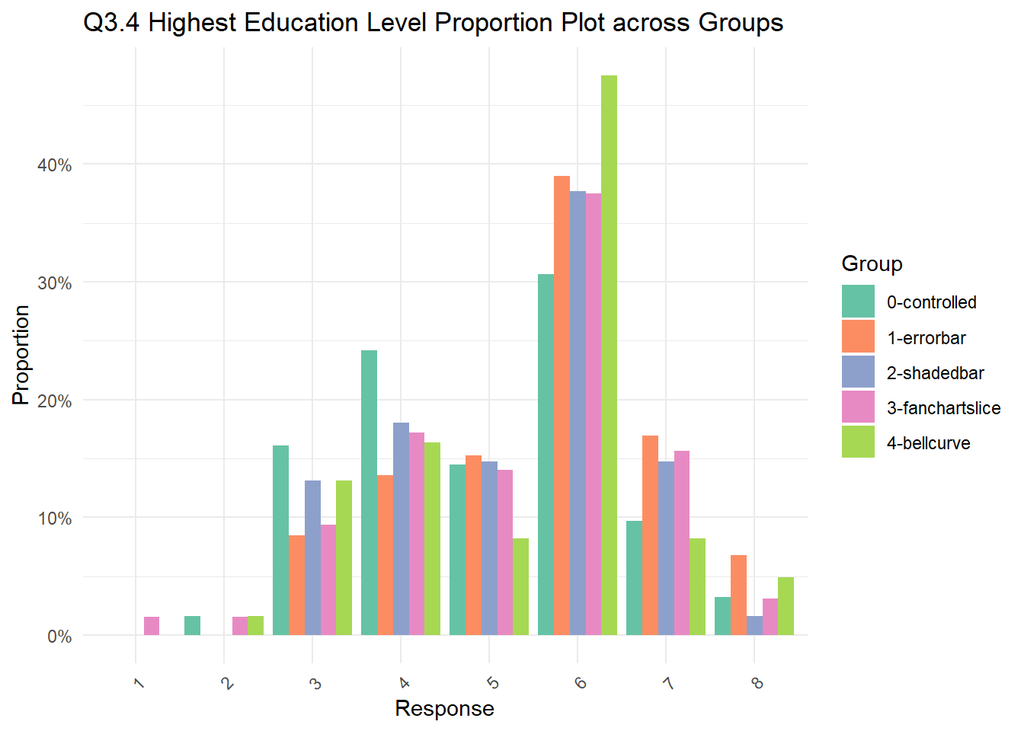

```r
q3_4_prop  <- as.data.frame(q3_4_contingency)
# rename columns
names(q3_4_prop) <- c("Q3.4", "Group", "Count")

# calculate proportions within each group
q3_4_prop <- q3_4_prop %>%
  group_by(Group) %>%
  mutate(Proportion = Count / sum(Count))

ggplot(q3_4_prop, aes(x = as.factor(`Q3.4`), y = Proportion, fill = Group)) +
  geom_bar(stat = "identity", position = "dodge") +
  # facet_wrap(~ Group) +
  labs(
    title = "Q3.4 Highest Education Level Proportion Plot across Groups",
    x = "Response",
    y = "Proportion"
  ) +
  # scale_x_discrete(labels = c(
  #   "1" = "No formal education",
  #   "2" = "Primary/Elementary",
  #   "3" = "Secondary School (GCSE)",
  #   "4" = "High School (A Level)",
  #   "5" = "Technical or Vocational",
  #   "6" = "Bachelors or equivalent degree level qualification",
  #   "7" = "Masters or equivalent higher degree level qualification",
  #   "8" = "PhD or equivalent doctoral level qualification"))+
   scale_fill_brewer(palette = "Set2")+
  scale_y_continuous(labels = scales::percent_format(accuracy = 1)) +
  theme_minimal() +
  theme(axis.text.x = element_text(angle = 45, hjust = 1))
```

Plot pie chart including all participants

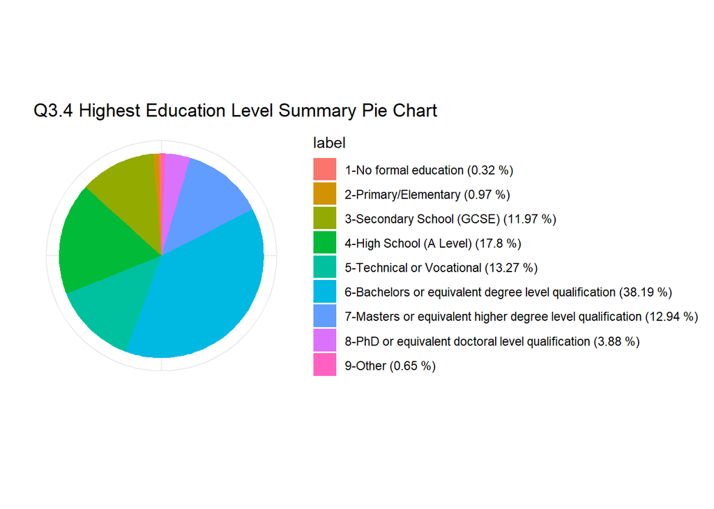

```r
q3_4_table <- rawdata_value[, c("Q3.4", "group")]

# Q3.4 summary table
q3_4_summary <- q3_4_table %>%
  group_by(`Q3.4`) %>%
  summarise(count = n()) %>%
  mutate(proportion = count / sum(count),
         label =
            case_when(
              Q3.4 == "1" ~ "1-No formal education",
              Q3.4 == "2" ~ "2-Primary/Elementary",
              Q3.4 == "3" ~ "3-Secondary School (GCSE)",
              Q3.4 == "4" ~ "4-High School (A Level)",
              Q3.4 == "5" ~ "5-Technical or Vocational",
              Q3.4 == "6" ~ "6-Bachelors or equivalent degree level qualification",
              Q3.4 == "7" ~ "7-Masters or equivalent higher degree level qualification",
              Q3.4 == "8" ~ "8-PhD or equivalent doctoral level qualification",
              Q3.4 == "9" ~ "9-Other"
            ),
         label = paste0(label, " (", round(proportion * 100, 2), " %)")
         )

ggplot(q3_4_summary, aes(x = "",y = proportion, fill = label)) +
  geom_col(width = 1) +
  coord_polar(theta = "y") +
  labs(title = "Q3.4 Highest Education Level Summary Pie Chart",
       x = "",
       y = "") +
  theme_minimal() +
  theme(axis.text.x = element_blank())
```

## Q3.5 Employee Status

What is your current profession or employment status?  
Variable: categorical  
Method: contingency Table + chi-squared test  
**Result: Fail to reject the null hypothesis**

```r
q3_5_table <- rawdata_value[rawdata_value$`Q3.5` != "6", c("Q3.5", "group")]
q3_5_contingency <- table(q3_5_table$Q3.5, q3_5_table$group)
# print(q3_5_contingency)

# Chi-squared test
chisq.test(q3_5_contingency)
```

```
##
##  Pearson's Chi-squared test
##
## data:  q3_5_contingency
## X-squared = 17.324, df = 16, p-value = 0.3649
```

Employee status proportion bar plot across different groups

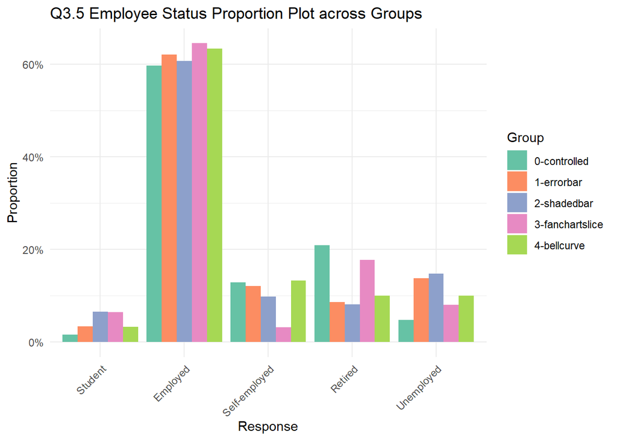

```r
q3_5_prop  <- as.data.frame(q3_5_contingency)
# rename columns
names(q3_5_prop) <- c("Q3.5", "Group", "Count")


# calculate proportions within each group
q3_5_prop <- q3_5_prop %>%
  group_by(Group) %>%
  mutate(Proportion = Count / sum(Count))

ggplot(q3_5_prop, aes(x = as.factor(`Q3.5`), y = Proportion, fill = Group)) +
  geom_bar(stat = "identity", position = "dodge") +
  # facet_wrap(~ Group) +
  labs(
    title = "Q3.5 Employee Status Proportion Plot across Groups",
    x = "Response",
    y = "Proportion"
  ) +
  scale_x_discrete(labels = c(
    "1" = "Student",
    "2" = "Employed",
    "3" = "Self-employed",
    "4" = "Retired",
    "5" = "Unemployed"
  )) +
   scale_fill_brewer(palette = "Set2")+
  scale_y_continuous(labels = scales::percent_format(accuracy = 1)) +
  theme_minimal() +
  theme(axis.text.x = element_text(angle = 45, hjust = 1))
```

Plot pie chart including all participants

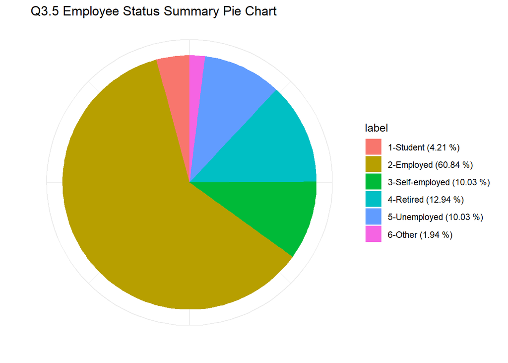

```r
q3_5_table <- rawdata_value[, c("Q3.5", "group")]
q3_5_summary <- q3_5_table %>%
  group_by(`Q3.5`) %>%
  summarise(count = n()) %>%
  mutate(proportion = count / sum(count),
         label =
            case_when(
              Q3.5 == "1" ~ "1-Student",
              Q3.5 == "2" ~ "2-Employed",
              Q3.5 == "3" ~ "3-Self-employed",
              Q3.5 == "4" ~ "4-Retired",
              Q3.5 == "5" ~ "5-Unemployed",
              Q3.5 == "6" ~ "6-Other"
            ),
         label = paste0(label, " (", round(proportion * 100, 2), " %)")
         )
ggplot(q3_5_summary, aes(x = "",y = proportion, fill = label)) +
  geom_col(width = 1) +
  coord_polar(theta = "y") +
  labs(title = "Q3.5 Employee Status Summary Pie Chart",
       x = "",
       y = "") +
  theme_minimal() +
  theme(axis.text.x = element_blank())
```

## Q3.6 Economics Education

In which, if any, have you ever studied economics? (Select all that apply)  
Variable: categorical  
Method: convert to list and count + chi-squared test  
**Result: Fail to reject the null hypothesis**

Plot percentage bar chart including all participants

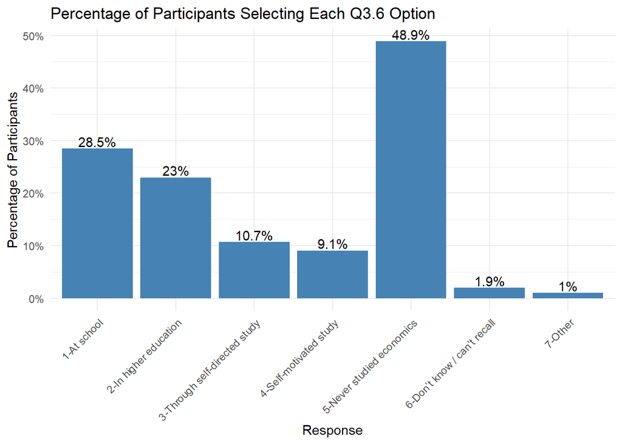

```r
q3_6_table <- rawdata_value[, c("Q3.6", "group")]
q3_6_table$Q3.6 <- lapply(q3_6_table$Q3.6, function(x) as.list(as.numeric(strsplit(x, ",")[[1]])))

# count the number of occurrences of each value
q3_6_summary <- q3_6_table %>%
  unnest(Q3.6) %>%
  group_by(`Q3.6`) %>%
  summarise(count = n()) %>%
  mutate(proportion = count / total_respondents,
         label =
            case_when(
              Q3.6 == "1" ~ "1-At school",
              Q3.6 == "2" ~ "2-In higher education",
              Q3.6 == "3" ~ "3-Through self-directed study",
              Q3.6 == "4" ~ "4-Self-motivated study",
              Q3.6 == "5" ~ "5-Never studied economics",
              Q3.6 == "6" ~ "6-Don’t know / can’t recall",
              Q3.6 == "7" ~ "7-Other"
            ))

# q3_6_summary$Q3.6 <- as.numeric(q3_6_summary$Q3.6)
ggplot(q3_6_summary, aes(x = factor(label), y = proportion)) +
  geom_col(fill = "steelblue") +
  geom_text(aes(label = paste0(round(proportion * 100, 1), "%")),
            vjust = -0.2) +
  scale_y_continuous(labels = scales::percent_format(accuracy = 1)) +
  labs(
    title = "Percentage of Participants Selecting Each Q3.6 Option",
    x = "Response",
    y = "Percentage of Participants"
  ) +
  theme_minimal() +
  theme(axis.text.x = element_text(angle = 45, hjust = 1))
```

```r
q3_6_table <- rawdata_value[, c("Q3.6", "group")]
q3_6_table$Q3.6 <- lapply(q3_6_table$Q3.6, function(x) as.list(as.numeric(strsplit(x, ",")[[1]])))
# count the number of occurrences of each value
q3_6_prop <- q3_6_table %>%
  unnest(Q3.6) %>%
  group_by(group, Q3.6) %>%
  summarise(count = n(), .groups = 'drop')
q3_6_prop$Q3.6 <- as.numeric(q3_6_prop$Q3.6)

# create a contingency table
q3_6_contingency <- xtabs(count ~ Q3.6 + group, data = q3_6_prop)
print(q3_6_contingency)
```

```
##     group
## Q3.6 0-controlled 1-errorbar 2-shadedbar 3-fanchartslice 4-bellcurve
##    1           18         19          13              17          21
##    2            8         14          17              20          12
##    3            4          9           8               7           5
##    4            4          7           5               8           4
##    5           37         27          29              30          28
##    6            2          0           1               1           2
##    7            0          2           0               0           1
```

```r
# Chi-squared test
chisq.test(q3_6_contingency)
```

```
##
##  Pearson's Chi-squared test
##
## data:  q3_6_contingency
## X-squared = 21.68, df = 24, p-value = 0.5983
```

```r
# q3_6_test <-q3_6_prop %>%
#   group_by(`Q3.6`) %>%
#   summarise(total_count = sum(count), .groups = "drop")
```

Economics Education proportion bar plot across different groups

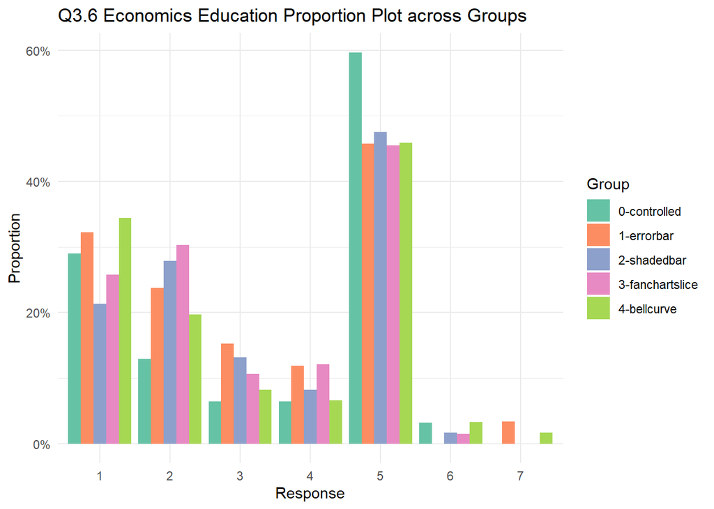

```r
# convert contingency table to data frame # count 0 as well
q3_6_prop <- as.data.frame(q3_6_contingency)
# calculate proportions within each group
q3_6_prop <- q3_6_prop %>%
  left_join(group_total, by = "group") %>%
  mutate(Proportion = Freq / n_respondents)

ggplot(q3_6_prop, aes(x = factor(Q3.6), y = Proportion, fill = factor(group))) +
  geom_col(position = "dodge") +
  labs(
    title = "Q3.6 Economics Education Proportion Plot across Groups",
    x = "Response",
    y = "Proportion",
    fill = "Group"
  ) +
  scale_fill_brewer(palette = "Set2")+
  scale_y_continuous(labels = scales::percent_format(accuracy = 1)) +
  theme_minimal()
```

## Q3.7 Financial Activities

Which of the following financial activities do you actively participate in? (Select all that apply) - Selected Choice Fixed Income (e.g., government bonds, corporate bonds)  
Variable: categorical  
Method: convert to list and count + chi-squared test  
**Result: Fail to reject the null hypothesis**

```r
q3_7_table <- rawdata_value[, c("Q3.7", "group")]
q3_7_table$Q3.7 <- lapply(q3_7_table$Q3.7, function(x) as.list(as.numeric(strsplit(x, ",")[[1]])))
# count the number of occurrences of each value in each group
q3_7_prop <- q3_7_table %>%
  unnest(Q3.7) %>%
  group_by(group,`Q3.7`) %>%
  summarise(count = n(), .groups = 'drop')
q3_7_prop$Q3.7 <- as.numeric(q3_7_prop$Q3.7)

# create a contingency table
q3_7_contingency <- xtabs(count ~ `Q3.7` + group, data = q3_7_prop)
print(q3_7_contingency)
```

```
##     group
## Q3.7 0-controlled 1-errorbar 2-shadedbar 3-fanchartslice 4-bellcurve
##   11           54         54          54              63          53
##   12           29         33          27              36          25
##   13            9         17           8               6          10
##   14           32         34          30              27          32
##   15            3         12           5               9           4
##   16            1          7           3               7           8
##   17           11         15          13              12           9
##   18            5          5           4               2           6
##   19            2          2           0               0           0
```

```r
# Chi-squared test
chisq.test(q3_7_contingency)
```

```
##
##  Pearson's Chi-squared test
##
## data:  q3_7_contingency
## X-squared = 30.965, df = 32, p-value = 0.5188
```

Plot financial activities proportion bar plot across different groups

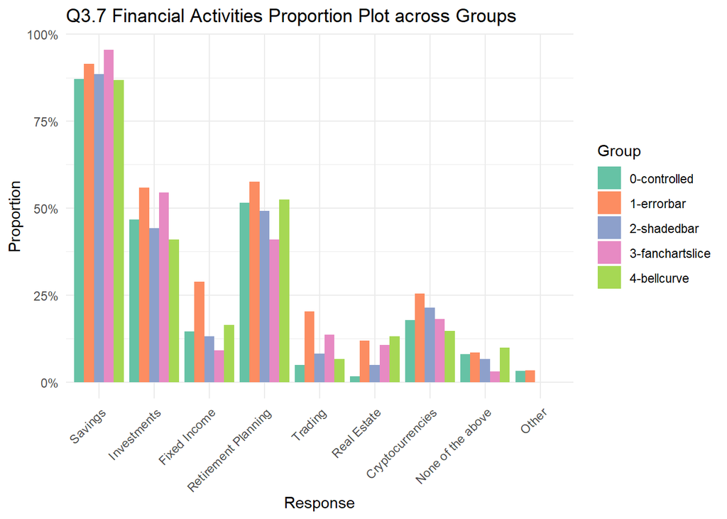

```r
# convert contingency table to data frame
q3_7_prop <- as.data.frame(q3_7_contingency) %>%
  left_join(group_total, by = "group") %>%
  mutate(Proportion = Freq / n_respondents)


ggplot(q3_7_prop, aes(x = factor(`Q3.7`), y = Proportion, fill = factor(group))) +
  geom_col(position = "dodge") +
  labs(
    title = "Q3.7 Financial Activities Proportion Plot across Groups",
    x = "Response",
    y = "Proportion",
    fill = "Group"
  ) +
    scale_x_discrete(labels = c(
    "11" = "Savings",
    "12" = "Investments",
    "13" = "Fixed Income",
    "14" = "Retirement Planning",
    "15" = "Trading",
    "16" = "Real Estate",
    "17" = "Cryptocurrencies",
    "18" = "None of the above",
    "19" = "Other"
      )) +
  scale_fill_brewer(palette = "Set2")+
  scale_y_continuous(labels = scales::percent_format(accuracy = 1)) +
  theme_minimal() +
  theme(axis.text.x = element_text(angle = 45, hjust = 1))
```

Plot percentage bar chart including all participants

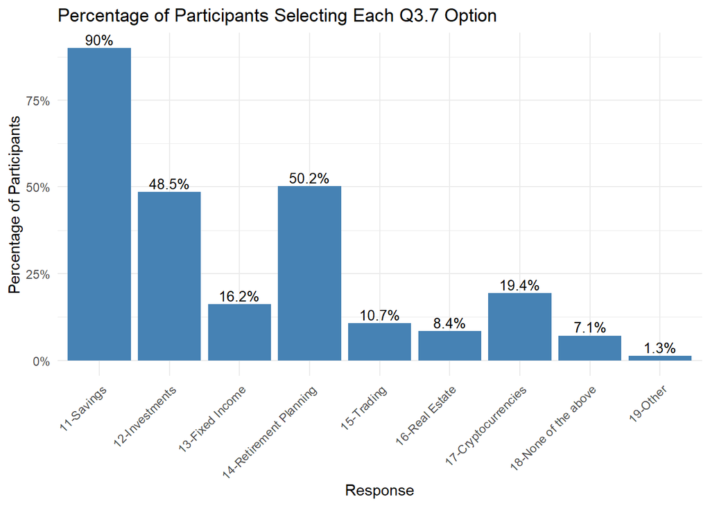

```r
q3_7_summary <-q3_7_prop %>%
  group_by(`Q3.7`) %>%
  summarise(total_count = sum(Freq), .groups = "drop") %>%
  mutate(proportion = total_count / total_respondents,
         label =
            case_when(
              `Q3.7` == "11" ~ "11-Savings",
              `Q3.7` == "12" ~ "12-Investments",
              `Q3.7` == "13" ~ "13-Fixed Income",
              `Q3.7` == "14" ~ "14-Retirement Planning",
              `Q3.7` == "15" ~ "15-Trading",
              `Q3.7` == "16" ~ "16-Real Estate",
              `Q3.7` == "17" ~ "17-Cryptocurrencies",
              `Q3.7` == "18" ~ "18-None of the above",
              `Q3.7` == "19" ~ "19-Other"
            ))

ggplot(q3_7_summary, aes(x = factor(label), y = proportion)) +
  geom_col(fill = "steelblue") +
  geom_text(aes(label = paste0(round(proportion * 100, 1), "%")),
            vjust = -0.3, size = 3.5) +
  scale_y_continuous(labels = scales::percent_format(accuracy = 1)) +
  labs(
    title = "Percentage of Participants Selecting Each Q3.7 Option",
    x = "Response",
    y = "Percentage of Participants"
  ) +
  theme_minimal() +
  theme(axis.text.x = element_text(angle = 45, hjust = 1))
```

## Q3.8 Awareness of Economics How frequently, if at all, do you read/watch/listen to news stories related to economics or the economy?  
Variable: categorical  
Method: contingency table + chi-squared test  
**Result: Fail to reject the null hypothesis**

```r
q3_8_table <- rawdata_value[, c("Q3.8", "group")]

q3_8_contingency <- table(q3_8_table$Q3.8, q3_8_table$group)
print(q3_8_contingency)
```

```
##
##     0-controlled 1-errorbar 2-shadedbar 3-fanchartslice 4-bellcurve
##   1            2          0           3               0           4
##   2           11         11          10              10           8
##   3            9          9           7              12          10
##   4           24         15          16              16          23
##   5           14         18          19              18          11
##   6            2          6           6               9           5
##   7            0          0           0               1           0
```

```r
# Chi-squared test
# chisq.test(q3_8_contingency)
chisq.test(q3_8_contingency[-nrow(q3_8_contingency), ])
```

```
##
##  Pearson's Chi-squared test
##
## data:  q3_8_contingency[-nrow(q3_8_contingency), ]
## X-squared = 20.071, df = 20, p-value = 0.4535
```

Awareness of Economics proportion bar plot across different groups

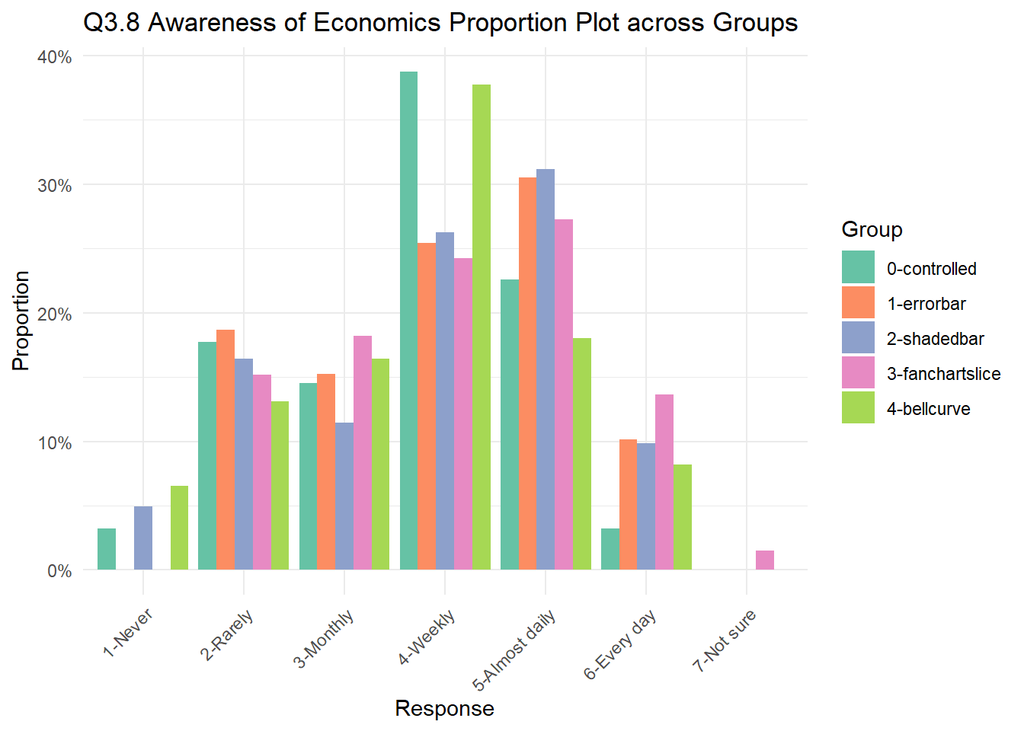

```r
q3_8_prop  <- as.data.frame(q3_8_contingency)
# rename columns
names(q3_8_prop) <- c("Q3.8", "Group", "Count")

# add a labelled column
q3_8_prop <- q3_8_prop %>%
  mutate(Q3.8_label = case_when(
    Q3.8 == "1" ~ "1-Never",
    Q3.8 == "2" ~ "2-Rarely",
    Q3.8 == "3" ~ "3-Monthly",
    Q3.8 == "4" ~ "4-Weekly",
    Q3.8 == "5" ~ "5-Almost daily",
    Q3.8 == "6" ~ "6-Every day",
    Q3.8 == "7" ~ "7-Not sure"
  ))

# calculate proportions within each group
q3_8_prop <- q3_8_prop %>%
  group_by(Group) %>%
  mutate(Proportion = Count / sum(Count))

ggplot(q3_8_prop, aes(x = as.factor(`Q3.8_label`), y = Proportion, fill = Group)) +
  geom_col(position = "dodge") +
  # facet_wrap(~ Group) +
  labs(
    title = "Q3.8 Awareness of Economics Proportion Plot across Groups",
    x = "Response",
    y = "Proportion"
  ) +
   scale_fill_brewer(palette = "Set2")+
  scale_y_continuous(labels = scales::percent_format(accuracy = 1)) +
  theme_minimal()+
  theme(axis.text.x = element_text(angle = 45, hjust = 1))
```

Plot pie chart including all participants

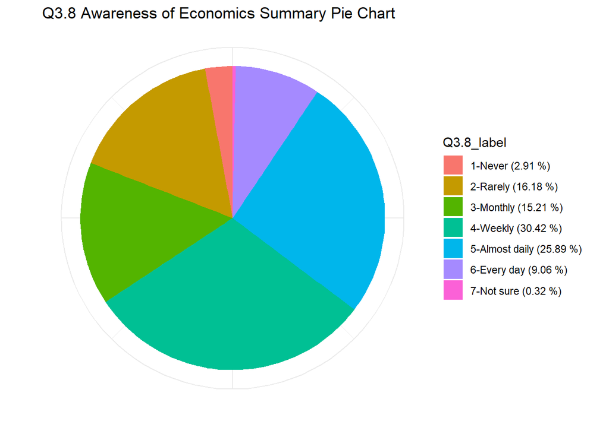

```r
q3_8_summary <- q3_8_prop %>%
  group_by(`Q3.8_label`) %>%
  summarise(total_count = sum(Count), .groups = "drop") %>%
  mutate(proportion = total_count / sum(total_count),
        `Q3.8_label` = paste0(`Q3.8_label`, " (", round(proportion * 100, 2), " %)"))
ggplot(q3_8_summary, aes(x = "",y = proportion, fill = `Q3.8_label`)) +
  geom_col(width = 1) +
  coord_polar(theta = "y") +
  labs(title = "Q3.8 Awareness of Economics Summary Pie Chart",
       x = "",
       y = "") +
  theme_minimal() +
  theme(axis.text.x = element_blank())
```

## Q3.9 Inflation Knowledge

To the best of your knowledge, which option most accurately describes what inflation is?  
Definitive correct answer  
Variable: categorical  
Method: descriptive analysis  
**Respondents were filtered based on whether if they can understand what inflation is.**

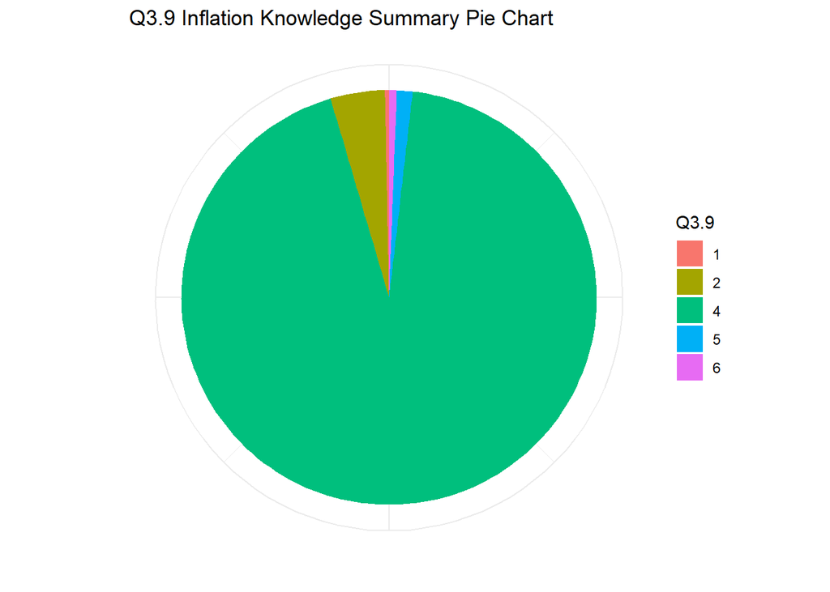

```r
q3_9_table <- rawdata_q3_9[, c("Q3.9", "group")]
q3_9_summary <- q3_9_table %>%
  group_by(`Q3.9`) %>%
  summarise(count = n()) %>%
  mutate(proportion = count / sum(count))

  ggplot(q3_9_summary, aes(x = "",y = proportion, fill = `Q3.9`)) +
  geom_col(width = 1) +
  coord_polar(theta = "y") +
  labs(title = "Q3.9 Inflation Knowledge Summary Pie Chart",
       x = "",
       y = "") +
  theme_minimal() +
  theme(axis.text.x = element_blank())
```

## Q3.11 Trust of Official Data

How much do you trust official inflation forecasts (For instance, the forecasts released by the Bank of England)?  
*ascending value-increasing trust + exclude 6- Unsure / no opinion*  
Variable: treat as continuous  
Method: Kruskal-Wallis test  
**Result: Fail to reject the null hypothesis**

```r
q3_11_table <- rawdata_value[rawdata_value$`Q3.11` != "6", c("Q3.11", "group")]
q3_11_table$Q3.11 <- as.numeric(q3_11_table$`Q3.11`)
# check normality --> Not normally distributed
# shapiro.test(q3_11_table$Q3.11)
# bartlett.test(`Q3.11` ~ group, data = q3_11_table)


# run kruskal test
kruskal_test <- kruskal.test(Q3.11 ~ group, data = q3_11_table)
print(kruskal_test)
```

```
##
##  Kruskal-Wallis rank sum test
##
## data:  Q3.11 by group
## Kruskal-Wallis chi-squared = 3.4585, df = 4, p-value = 0.4842
```

```r
q3_11_summary <- q3_11_table %>%
  group_by(group) %>%
  summarise(q3_11_mean = mean(as.numeric(Q3.11), na.rm = TRUE),
            q3_11_sd = sd(as.numeric(Q3.11), na.rm = TRUE),
            .groups = 'drop')

# report quantile information
summary(q3_11_table$Q3.11)
```

```
##    Min. 1st Qu.  Median    Mean 3rd Qu.    Max.
##   1.000   3.000   4.000   3.711   4.000   5.000
```

Plot the distribution of different groups

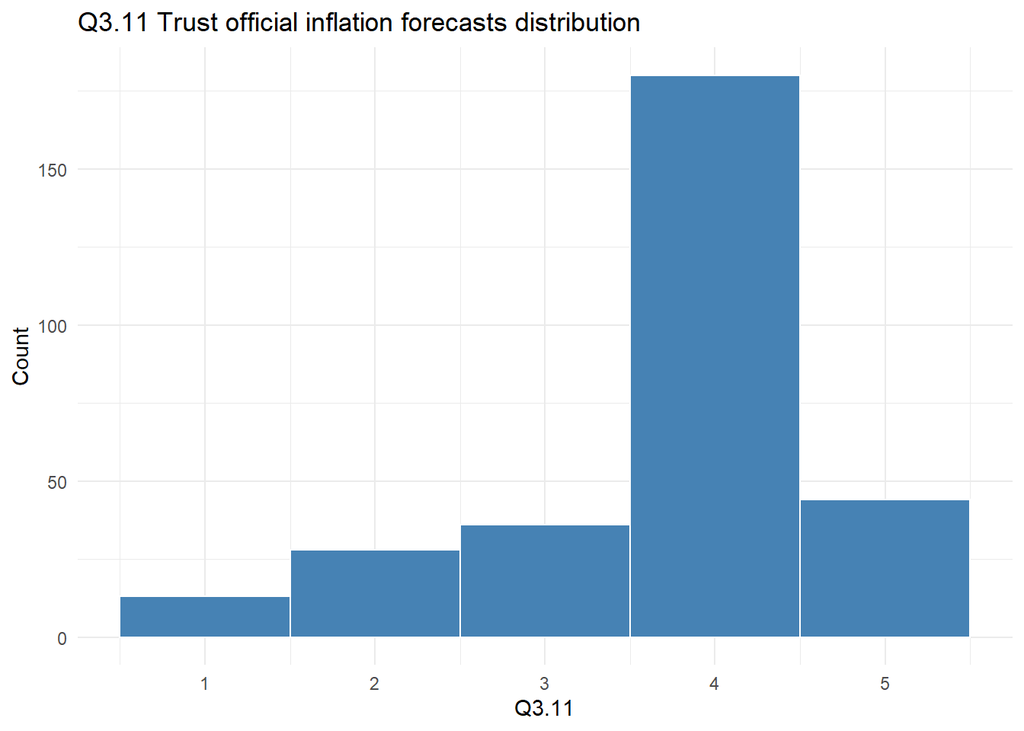

```r
# histogram including all participants
ggplot(q3_11_table, aes(x = Q3.11)) +
  geom_histogram(binwidth = 1, fill = "steelblue", color = "white") +
  # facet_wrap(~ group) +
  labs(title = "Q3.11 Trust official inflation forecasts distribution",
       x = "Q3.11",
       y = "Count") +
  scale_x_continuous(breaks = seq(0, max(q3_11_table$Q3.11, na.rm = TRUE), by = 1)) +
  theme_minimal()
```

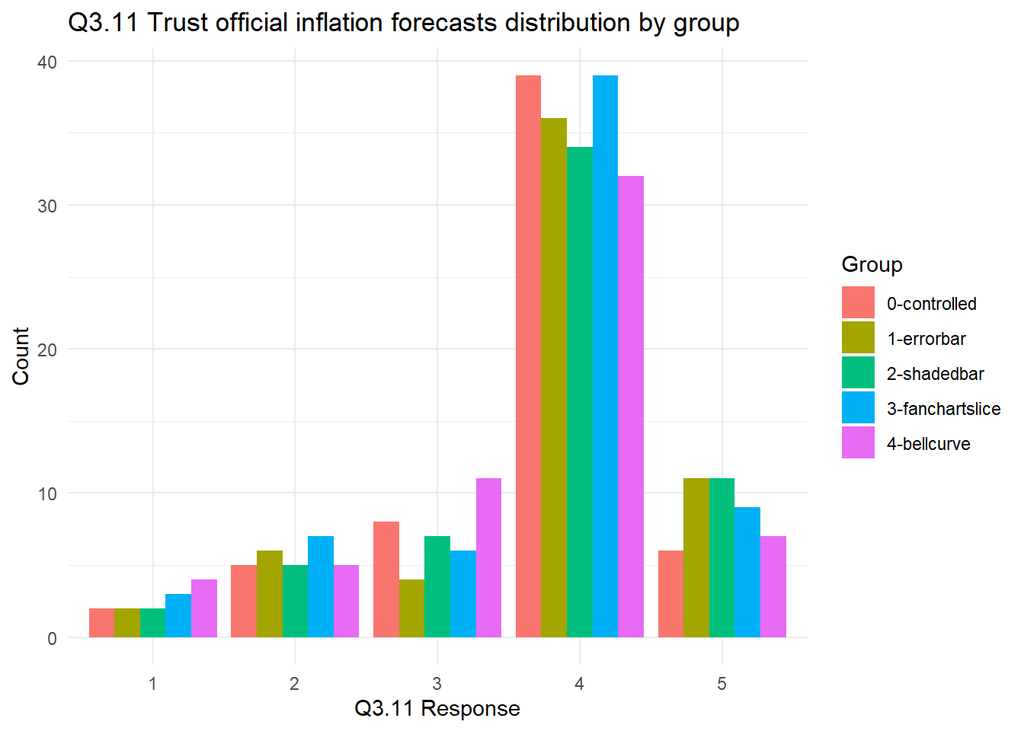

```r
# Grouped bar-style histogram
ggplot(q3_11_table, aes(x = factor(Q3.11), fill = factor(group))) +
  geom_bar(position = "dodge") +
  labs(
    title = "Q3.11 Trust official inflation forecasts distribution by group",
    x = "Q3.11 Response",
    y = "Count",
    fill = "Group"
  ) +
  theme_minimal()
```

## Q3.12 Frequency of Checking Current Inflation

How often do you check the current value of inflation? Variable: categorical  
Method: contingency table + chi-squared test  
**Result: Fail to reject the null hypothesis**

```r
# Initial Check
summary(as.numeric(rawdata_value$Q3.12))
```

```
##    Min. 1st Qu.  Median    Mean 3rd Qu.    Max.
##   1.000   2.000   2.000   2.417   3.000   4.000
```

```r
q3_12_table <- rawdata_value[, c("Q3.12", "group")]
q3_12_contingency <- table(q3_12_table$Q3.12, q3_12_table$group)
print(q3_12_contingency)
```

```
##
##     0-controlled 1-errorbar 2-shadedbar 3-fanchartslice 4-bellcurve
##   1            5          4           8               7           6
##   2           35         25          30              21          28
##   3           17         25          21              32          26
##   4            5          5           2               6           1
```

```r
# Chi-squared test
chisq.test(q3_12_contingency)
```

```
##
##  Pearson's Chi-squared test
##
## data:  q3_12_contingency
## X-squared = 15.166, df = 12, p-value = 0.2325
```

Frequency of Checking Current Inflation proportion bar plot across different groups

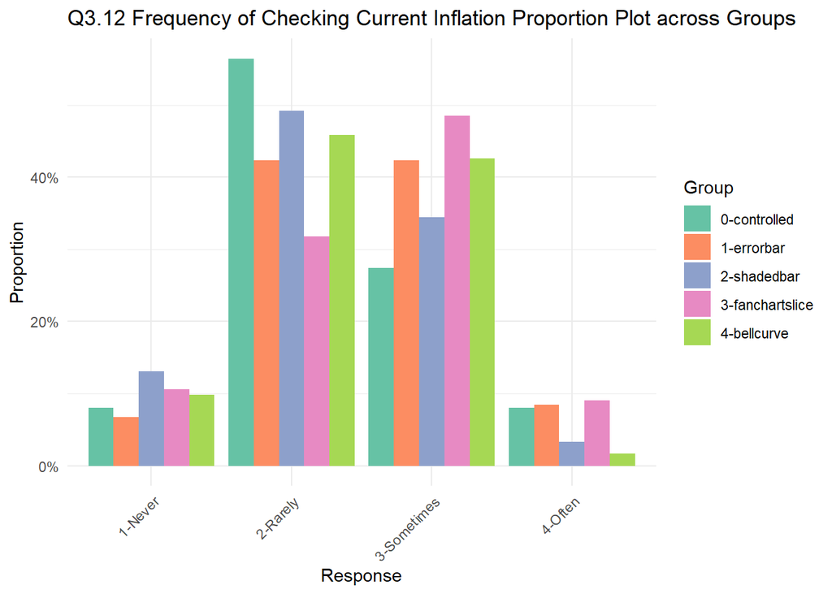

```r
q3_12_prop  <- as.data.frame(q3_12_contingency)
# rename columns
names(q3_12_prop) <- c("Q3.12", "Group", "Count")

# add a labelled column
q3_12_prop <- q3_12_prop %>%
  mutate(Q3.12_label = case_when(
    Q3.12 == "1" ~ "1-Never",
    Q3.12 == "2" ~ "2-Rarely",
    Q3.12 == "3" ~ "3-Sometimes",
    Q3.12 == "4" ~ "4-Often"
  ))
# calculate proportions within each group
q3_12_prop <- q3_12_prop %>%
  group_by(Group) %>%
  mutate(Proportion = Count / sum(Count))

ggplot(q3_12_prop, aes(x = as.factor(`Q3.12_label`), y = Proportion, fill = Group)) + geom_col(position = "dodge") +
  labs(
    title = "Q3.12 Frequency of Checking Current Inflation Proportion Plot across Groups",
    x = "Response",
    y = "Proportion"
  ) +
   scale_fill_brewer(palette = "Set2")+
  scale_y_continuous(labels = scales::percent_format(accuracy = 1)) +
  theme_minimal()+
  theme(axis.text.x = element_text(angle = 45, hjust = 1))
```

Plot pie chart including all participants

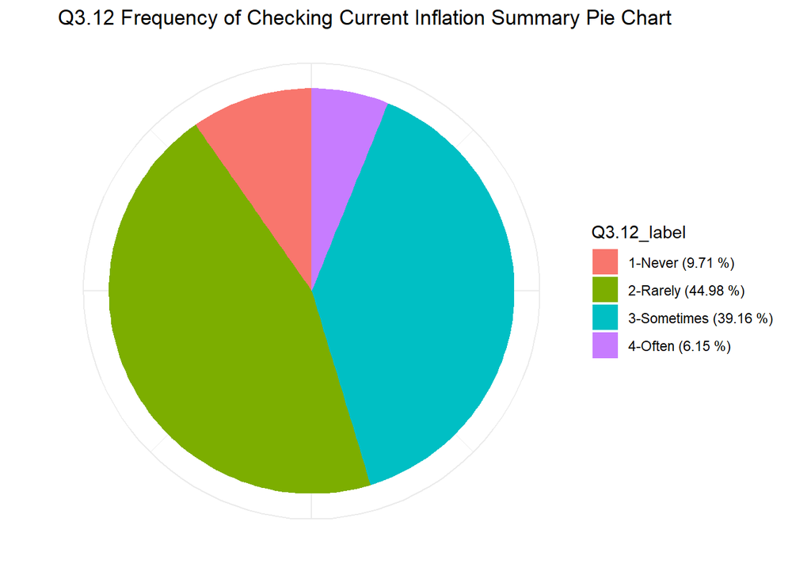

```r
q3_12_summary <- q3_12_prop %>%
  group_by(`Q3.12_label`) %>%
  summarise(total_count = sum(Count), .groups = "drop") %>%
  mutate(proportion = total_count / sum(total_count),
         `Q3.12_label` = paste0(`Q3.12_label`, " (", round(proportion * 100, 2), " %)"))
ggplot(q3_12_summary, aes(x = "",y = proportion, fill = `Q3.12_label`)) +
  geom_col(width = 1) +
  coord_polar(theta = "y") +
  labs(title = "Q3.12 Frequency of Checking Current Inflation Summary Pie Chart",
       x = "",
       y = "") +
  theme_minimal() +
  theme(axis.text.x = element_blank())
```

## Q3.13 Source of Current Inflation

Which source do you rely on to inform yourself about the current value of inflation?  
Variable: categorical  
Method: convert to list and count + chi-squared test  
**Result: Fail to reject the null hypothesis**

```r
q3_13_table <- rawdata_value[, c("Q3.13", "group")]
q3_13_table$Q3.13 <- lapply(q3_13_table$Q3.13, function(x) as.list(as.numeric(strsplit(x, ",")[[1]])))
# count the number of occurrences of each value
q3_13_prop <- q3_13_table %>%
  unnest(Q3.13) %>%
  group_by(group,`Q3.13`) %>%
  summarise(count = n(), .groups = 'drop')
q3_13_prop$Q3.13 <- as.numeric(q3_13_prop$Q3.13)
# create a contingency table
q3_13_contingency <- xtabs(count ~ `Q3.13` + group, data = q3_13_prop)
print(q3_13_contingency)
```

```
##      group
## Q3.13 0-controlled 1-errorbar 2-shadedbar 3-fanchartslice 4-bellcurve
##     1           43         41          33              44          36
##     2           16         16          15              13          16
##     3           24         28          26              29          21
##     4            5          7           8               4          10
##     5           15         15          22              21          17
##     6            6          6           7               4          11
##     7           15         13          15              19          13
##     8            5          8           5               5           1
##     9            2          0           0               0           0
```

```r
# Chi-squared test
chisq.test(q3_13_contingency)
```

```
##
##  Pearson's Chi-squared test
##
## data:  q3_13_contingency
## X-squared = 28.283, df = 32, p-value = 0.6553
```

Plot source of current inflation proportion bar plot across different groups

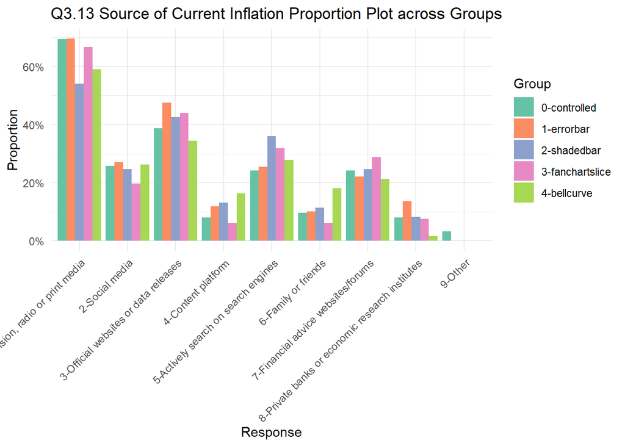

```r
# convert contingency table to data frame
q3_13_prop <- as.data.frame(q3_13_contingency) %>%
  left_join(group_total, by = "group") %>%
  mutate(Proportion = Freq / n_respondents)

# add a labelled column
q3_13_prop <- q3_13_prop %>%
  mutate(Q3.13_label = case_when(
    `Q3.13` == "1" ~ "1-Television, radio or print media",
    `Q3.13` == "2" ~ "2-Social media",
    `Q3.13` == "3" ~ "3-Official websites or data releases",
    `Q3.13` == "4" ~ "4-Content platform",
    `Q3.13` == "5" ~ "5-Actively search on search engines",
    `Q3.13` == "6" ~ "6-Family or friends",
    `Q3.13` == "7" ~ "7-Financial advice websites/forums",
    `Q3.13` == "8" ~ "8-Private banks or economic research institutes",
    `Q3.13` == "9" ~ "9-Other"
  ))
ggplot(q3_13_prop, aes(x = factor(`Q3.13_label`), y = Proportion, fill = group)) +
  geom_col(position = "dodge") +
  labs(
    title = "Q3.13 Source of Current Inflation Proportion Plot across Groups",
    x = "Response",
    y = "Proportion",
    fill = "Group"
  ) +
   scale_fill_brewer(palette = "Set2")+
  scale_y_continuous(labels = scales::percent_format(accuracy = 1)) +
  theme_minimal() +
  theme(axis.text.x = element_text(angle = 45, hjust = 1))
```

Plot percentage bar chart including all participants

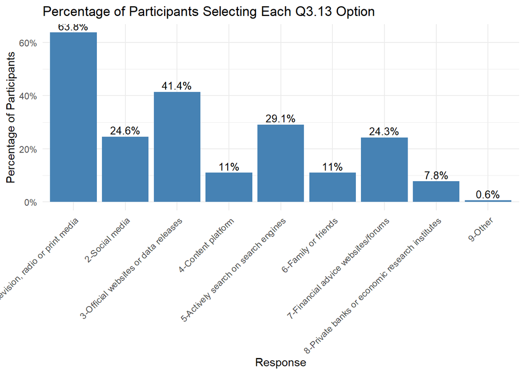

```r
q3_13_summary <- q3_13_prop %>%
  group_by(`Q3.13_label`) %>%
  summarise(total_count = sum(Freq), .groups = "drop") %>%
  mutate(proportion = total_count / total_respondents)

ggplot(q3_13_summary, aes(x = factor(Q3.13_label), y = proportion)) +
  geom_col(fill = "steelblue") +
  geom_text(aes(label = paste0(round(proportion * 100, 1), "%")),
            vjust = -0.3, size = 3.5) +
  scale_y_continuous(labels = scales::percent_format(accuracy = 1)) +
  labs(
    title = "Percentage of Participants Selecting Each Q3.13 Option",
    x = "Response",
    y = "Percentage of Participants"
  ) +
  theme_minimal() +
  theme(axis.text.x = element_text(angle = 45, hjust = 1))
```

## Q3.14 Impact of Current Inflation

To what extent do you feel that the current value of inflation is impacting your personal finances? Variable: categorical  
Method: contingency table + chi-squared test  
**Result: Fail to reject the null hypothesis**

```r
# Initial Check
summary(as.numeric(rawdata_value$Q3.14))
```

```
##    Min. 1st Qu.  Median    Mean 3rd Qu.    Max.
##   1.000   2.000   3.000   2.816   3.000   4.000
```

```r
q3_14_table <- rawdata_value[, c("Q3.14", "group")]
q3_14_contingency <- table(q3_14_table$Q3.14, q3_14_table$group)
print(q3_14_contingency)
```

```
##
##     0-controlled 1-errorbar 2-shadedbar 3-fanchartslice 4-bellcurve
##   1            3          0           4               1           1
##   2           23         17          18              21          20
##   3           25         32          30              29          25
##   4           11         10           9              15          15
```

```r
# Chi-squared test
chisq.test(q3_14_contingency)
```

```
##
##  Pearson's Chi-squared test
##
## data:  q3_14_contingency
## X-squared = 10.903, df = 12, p-value = 0.5373
```

Impact of Current Inflation proportion bar plot across different groups

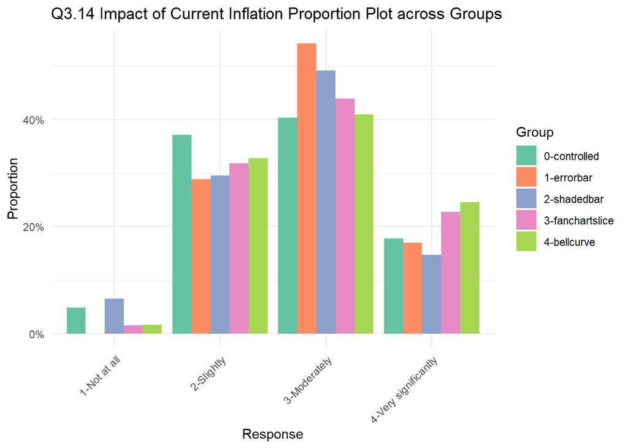

```r
q3_14_prop  <- as.data.frame(q3_14_contingency)
# rename columns
names(q3_14_prop) <- c("Q3.14", "Group", "Count")
# add a labelled column
q3_14_prop <- q3_14_prop %>%
  mutate(Q3.14_label = case_when(
    Q3.14 == "1" ~ "1-Not at all",
    Q3.14 == "2" ~ "2-Slightly",
    Q3.14 == "3" ~ "3-Moderately",
    Q3.14 == "4" ~ "4-Very significantly"
  ))
# calculate proportions within each group
q3_14_prop <- q3_14_prop %>%
  group_by(Group) %>%
  mutate(Proportion = Count / sum(Count))
ggplot(q3_14_prop, aes(x = as.factor(`Q3.14_label`), y = Proportion, fill = Group)) + geom_col(position = "dodge") +
  labs(
    title = "Q3.14 Impact of Current Inflation Proportion Plot across Groups",
    x = "Response",
    y = "Proportion"
  ) +
   scale_fill_brewer(palette = "Set2")+
  scale_y_continuous(labels = scales::percent_format(accuracy = 1)) +
  theme_minimal()+
  theme(axis.text.x = element_text(angle = 45, hjust = 1))
```

Plot pie chart including all participants

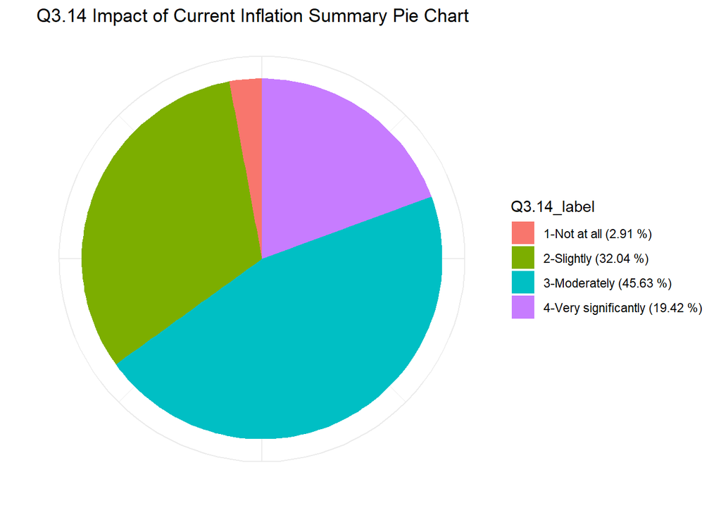

```r
q3_14_summary <- q3_14_prop %>%
  group_by(`Q3.14_label`) %>%
  summarise(total_count = sum(Count), .groups = "drop") %>%
  mutate(proportion = total_count / sum(total_count),
        `Q3.14_label` = paste0(`Q3.14_label`, " (", round(proportion * 100, 2), " %)"))
ggplot(q3_14_summary, aes(x = "",y = proportion, fill = `Q3.14_label`)) +
  geom_col(width = 1) +
  coord_polar(theta = "y") +
  labs(title = "Q3.14 Impact of Current Inflation Summary Pie Chart",
       x = "",
       y = "") +
  theme_minimal() +
  theme(axis.text.x = element_blank())
```

## Q3.15 Response to Current Inflation

How much do you adjust or take action in response to the change in current value of inflation?  
Variable: categorical  
Method: contingency table + chi-squared test  
**Result: Fail to reject the null hypothesis**

```r
# Initial Check
summary(as.numeric(rawdata_value$Q3.15))
```

```
##    Min. 1st Qu.  Median    Mean 3rd Qu.    Max.
##    1.00    2.00    3.00    2.57    3.00    4.00
```

```r
q3_15_table <- rawdata_value[, c("Q3.15", "group")]
q3_15_contingency <- table(q3_15_table$Q3.15, q3_15_table$group)
print(q3_15_contingency)
```

```
##
##     0-controlled 1-errorbar 2-shadedbar 3-fanchartslice 4-bellcurve
##   1            7          2           7              10           6
##   2           24         20          22              15          19
##   3           25         28          25              36          32
##   4            6          9           7               5           4
```

```r
# Chi-squared test
chisq.test(q3_15_contingency)
```

```
##
##  Pearson's Chi-squared test
##
## data:  q3_15_contingency
## X-squared = 12.467, df = 12, p-value = 0.4089
```

Response to Current Inflation proportion bar plot across different groups

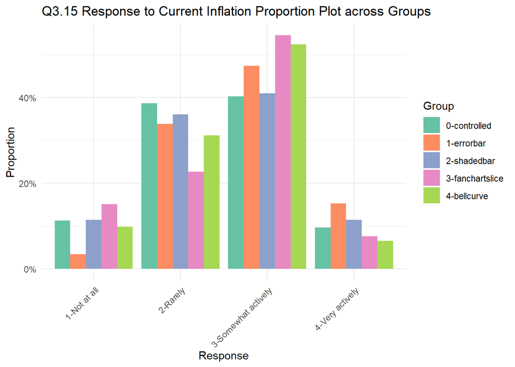

```r
q3_15_prop  <- as.data.frame(q3_15_contingency)
# rename columns
names(q3_15_prop) <- c("Q3.15", "Group", "Count")
# add a labelled column
q3_15_prop <- q3_15_prop %>%
  mutate(Q3.15_label = case_when(
    Q3.15 == "1" ~ "1-Not at all",
    Q3.15 == "2" ~ "2-Rarely",
    Q3.15 == "3" ~ "3-Somewhat actively",
    Q3.15 == "4" ~ "4-Very actively"
  ))
# calculate proportions within each group
q3_15_prop <- q3_15_prop %>%
  group_by(Group) %>%
  mutate(Proportion = Count / sum(Count))
ggplot(q3_15_prop, aes(x = as.factor(`Q3.15_label`), y = Proportion, fill = Group)) + geom_col(position = "dodge") +
  labs(
    title = "Q3.15 Response to Current Inflation Proportion Plot across Groups",
    x = "Response",
    y = "Proportion"
  ) +
   scale_fill_brewer(palette = "Set2")+
  scale_y_continuous(labels = scales::percent_format(accuracy = 1)) +
  theme_minimal()+
  theme(axis.text.x = element_text(angle = 45, hjust = 1))
```

Plot pie chart including all participants

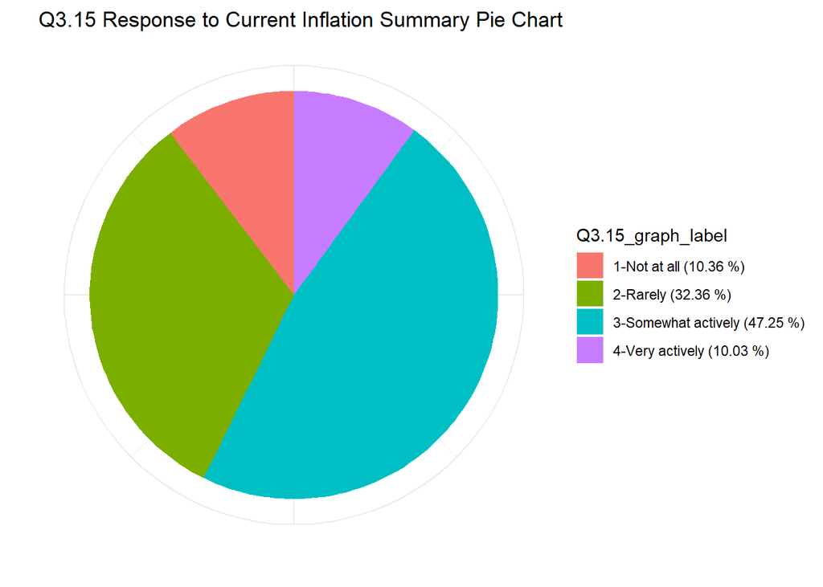

```r
q3_15_summary <- q3_15_prop %>%
  group_by(`Q3.15_label`) %>%
  summarise(total_count = sum(Count), .groups = "drop") %>%
  mutate(proportion = total_count / sum(total_count),
         `Q3.15_graph_label` = paste0(`Q3.15_label`, " (", round(proportion * 100, 2), " %)"))
ggplot(q3_15_summary, aes(x = "",y = proportion, fill = `Q3.15_graph_label`)) +
  geom_col(width = 1) +
  coord_polar(theta = "y") +
  labs(title = "Q3.15 Response to Current Inflation Summary Pie Chart",
       x = "",
       y = "") +
  theme_minimal() +
  theme(axis.text.x = element_blank())
```

## Q3.16 Frequency of Checking Inflation Forecasts

How often do you look at inflation forecasts (that is, information about future inflation)?  
Variable: categorical  
Method: contingency table + chi-squared test  
**Result: Fail to reject the null hypothesis**

```r
# Initial Check
summary(as.numeric(rawdata_value$Q3.16))
```

```
##    Min. 1st Qu.  Median    Mean 3rd Qu.    Max.
##   1.000   2.000   2.000   2.181   3.000   4.000
```

```r
q3_16_table <- rawdata_value[, c("Q3.16", "group")]
q3_16_contingency <- table(q3_16_table$Q3.16, q3_16_table$group)
print(q3_16_contingency)
```

```
##
##     0-controlled 1-errorbar 2-shadedbar 3-fanchartslice 4-bellcurve
##   1            9         14          13              11          11
##   2           39         23          26              31          31
##   3           10         19          20              20          19
##   4            4          3           2               4           0
```

```r
# Chi-squared test
chisq.test(q3_16_contingency)
```

```
##
##  Pearson's Chi-squared test
##
## data:  q3_16_contingency
## X-squared = 14.353, df = 12, p-value = 0.2787
```

Frequency of Checking Inflation Forecasts proportion bar plot across different groups

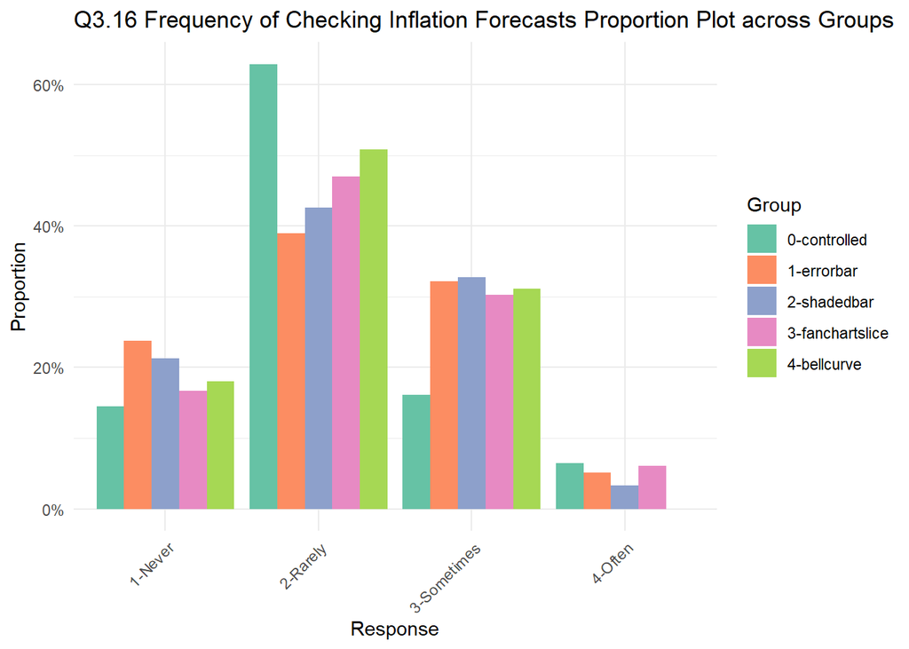

```r
q3_16_prop  <- as.data.frame(q3_16_contingency)
# rename columns
names(q3_16_prop) <- c("Q3.16", "Group", "Count")
# add a labelled column
q3_16_prop <- q3_16_prop %>%
  mutate(Q3.16_label = case_when(
    Q3.16 == "1" ~ "1-Never",
    Q3.16 == "2" ~ "2-Rarely",
    Q3.16 == "3" ~ "3-Sometimes",
    Q3.16 == "4" ~ "4-Often"
  ))
# calculate proportions within each group
q3_16_prop <- q3_16_prop %>%
  group_by(Group) %>%
  mutate(Proportion = Count / sum(Count))
ggplot(q3_16_prop, aes(x = as.factor(`Q3.16_label`), y = Proportion, fill = Group)) + geom_col(position = "dodge") +
  labs(
    title = "Q3.16 Frequency of Checking Inflation Forecasts Proportion Plot across Groups",
    x = "Response",
    y = "Proportion"
  ) +
   scale_fill_brewer(palette = "Set2")+
  scale_y_continuous(labels = scales::percent_format(accuracy = 1)) +
  theme_minimal()+
  theme(axis.text.x = element_text(angle = 45, hjust = 1))
```

Plot pie chart including all participants

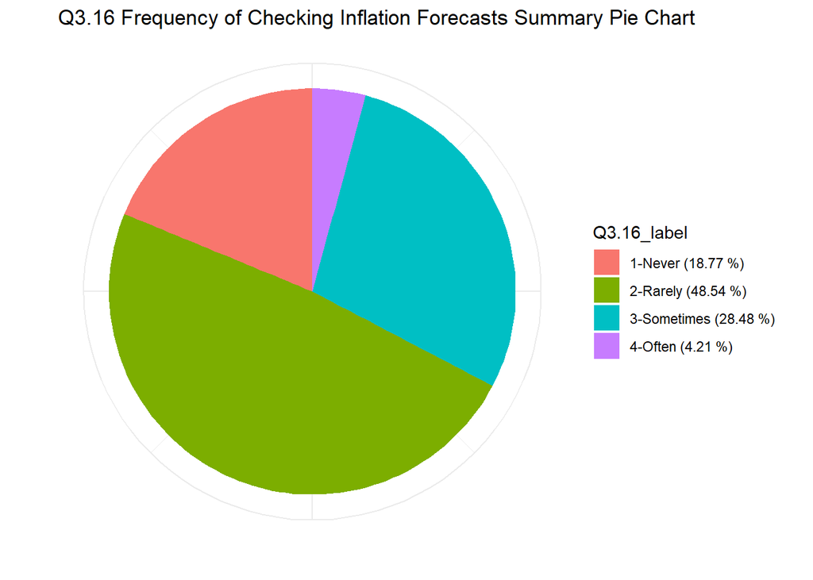

```r
q3_16_summary <- q3_16_prop %>%
  group_by(`Q3.16_label`) %>%
  summarise(total_count = sum(Count), .groups = "drop") %>%
  mutate(proportion = total_count / sum(total_count),
         `Q3.16_label` = paste0(`Q3.16_label`, " (", round(proportion * 100, 2), " %)"))
ggplot(q3_16_summary, aes(x = "",y = proportion, fill = `Q3.16_label`)) +
  geom_col(width = 1) +
  coord_polar(theta = "y") +
  labs(title = "Q3.16 Frequency of Checking Inflation Forecasts Summary Pie Chart",
       x = "",
       y = "") +
  theme_minimal() +
  theme(axis.text.x = element_blank())
```

## Q3.17 Source of Inflation Forecasts

Which source do you rely on to obtain inflation forecasts (information about future inflation)?  
Variable: categorical  
Method: convert to list and count + chi-squared test  
**Result: Fail to reject the null hypothesis**

```r
q3_17_table <- rawdata_value[, c("Q3.17", "group")]
q3_17_table$Q3.17 <- lapply(q3_17_table$Q3.17, function(x) as.list(as.numeric(strsplit(x, ",")[[1]])))
# count the number of occurrences of each value
q3_17_prop <- q3_17_table %>%
  unnest(Q3.17) %>%
  group_by(group,`Q3.17`) %>%
  summarise(count = n(), .groups = 'drop')
q3_17_prop$Q3.17 <- as.numeric(q3_17_prop$Q3.17)
# create a contingency table
q3_17_contingency <- xtabs(count ~ `Q3.17` + group, data = q3_17_prop)
print(q3_17_contingency)
```

```
##      group
## Q3.17 0-controlled 1-errorbar 2-shadedbar 3-fanchartslice 4-bellcurve
##     1           38         30          33              35          33
##     2           17         14          14              11          13
##     3           16         22          23              29          22
##     4            5          9           8               4           7
##     5           14         16          18              17          13
##     6            4          4           7               4           8
##     7           15         16          16              20          16
##     8            5          9           4               6           2
##     9            2          0           0               0           0
```

```r
# Chi-squared test
chisq.test(q3_17_contingency)
```

```
##
##  Pearson's Chi-squared test
##
## data:  q3_17_contingency
## X-squared = 26.222, df = 32, p-value = 0.7537
```

Plot source of inflation forecasts proportion bar plot across different groups

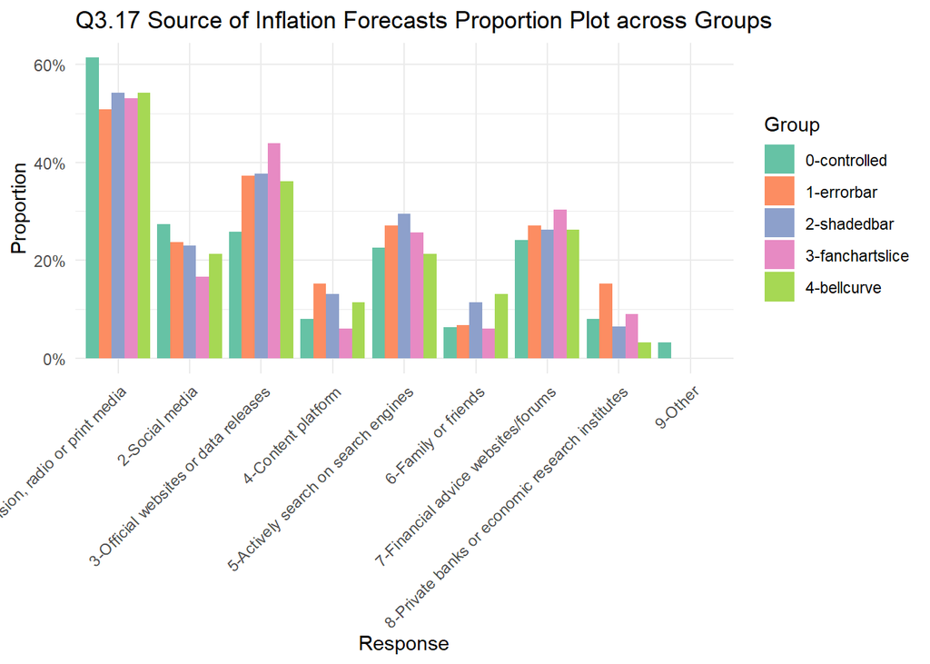

```r
# convert contingency table to data frame
q3_17_prop <- as.data.frame(q3_17_contingency) %>%
  left_join(group_total, by = "group") %>%
  mutate(Proportion = Freq / n_respondents)
# add a labelled column
q3_17_prop <- q3_17_prop %>%
  mutate(Q3.17_label = case_when(
    `Q3.17` == "1" ~ "1-Television, radio or print media",
    `Q3.17` == "2" ~ "2-Social media",
    `Q3.17` == "3" ~ "3-Official websites or data releases",
    `Q3.17` == "4" ~ "4-Content platform",
    `Q3.17` == "5" ~ "5-Actively search on search engines",
    `Q3.17` == "6" ~ "6-Family or friends",
    `Q3.17` == "7" ~ "7-Financial advice websites/forums",
    `Q3.17` == "8" ~ "8-Private banks or economic research institutes",
    `Q3.17` == "9" ~ "9-Other"
  ))
ggplot(q3_17_prop, aes(x = factor(`Q3.17_label`), y = Proportion, fill = group)) +
  geom_col(position = "dodge") +
  labs(
    title = "Q3.17 Source of Inflation Forecasts Proportion Plot across Groups",
    x = "Response",
    y = "Proportion",
    fill = "Group"
  ) +
   scale_fill_brewer(palette = "Set2")+
  scale_y_continuous(labels = scales::percent_format(accuracy = 1)) +
  theme_minimal() +
  theme(axis.text.x = element_text(angle = 45, hjust = 1))
```

Plot percentage bar chart including all participants

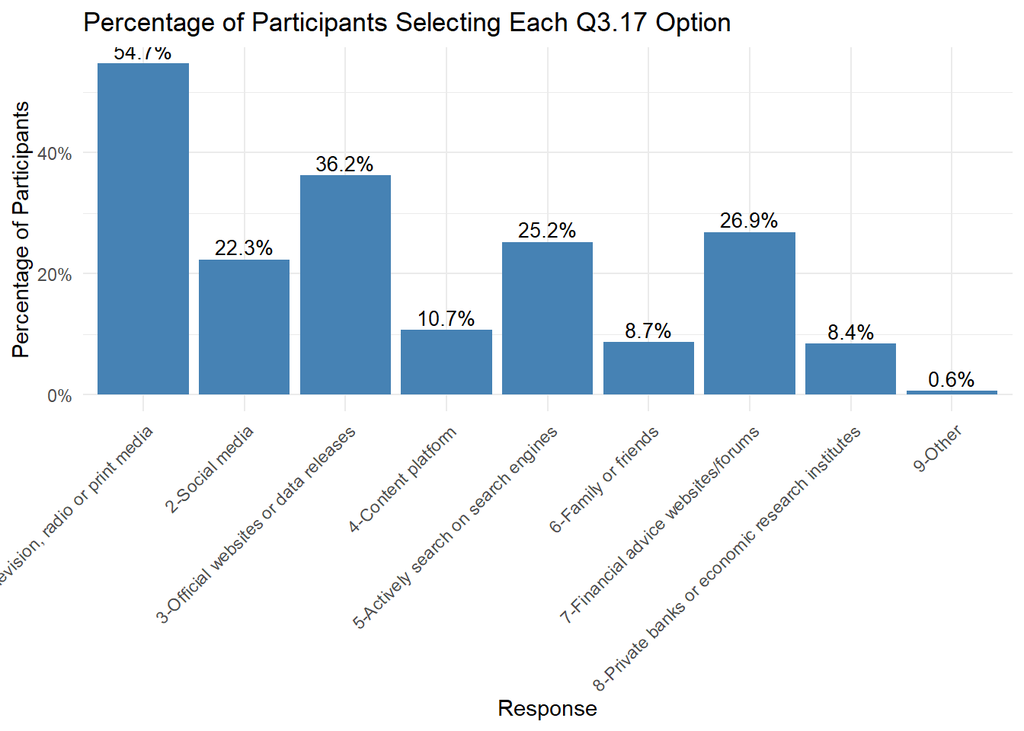

```r
q3_17_summary <- q3_17_prop %>%
  group_by(`Q3.17_label`) %>%
  summarise(total_count = sum(Freq), .groups = "drop") %>%
  mutate(proportion = total_count / total_respondents)
ggplot(q3_17_summary, aes(x = factor(Q3.17_label), y = proportion)) +
  geom_col(fill = "steelblue") +
  geom_text(aes(label = paste0(round(proportion * 100, 1), "%")),
            vjust = -0.3, size = 3.5) +
  scale_y_continuous(labels = scales::percent_format(accuracy = 1)) +
  labs(
    title = "Percentage of Participants Selecting Each Q3.17 Option",
    x = "Response",
    y = "Percentage of Participants"
  ) +
  theme_minimal() +
  theme(axis.text.x = element_text(angle = 45, hjust = 1))
```

## Q3.18 Impact of Inflation Forecasts

To what extent do you feel that inflation forecasts (information about future inflation) impact your personal finances?  
Variable: categorical  
Method: contingency table + chi-squared test  
**Result: Fail to reject the null hypothesis**

```r
# Initial Check
summary(as.numeric(rawdata_value$Q3.18))
```

```
##    Min. 1st Qu.  Median    Mean 3rd Qu.    Max.
##   1.000   2.000   2.000   2.301   3.000   4.000
```

```r
q3_18_table <- rawdata_value[, c("Q3.18", "group")]
q3_18_contingency <- table(q3_18_table$Q3.18, q3_18_table$group)
print(q3_18_contingency)
```

```
##
##     0-controlled 1-errorbar 2-shadedbar 3-fanchartslice 4-bellcurve
##   1           13         10          15               9           9
##   2           25         28          20              30          26
##   3           21         15          21              21          21
##   4            3          6           5               6           5
```

```r
# Chi-squared test
chisq.test(q3_18_contingency)
```

```
##
##  Pearson's Chi-squared test
##
## data:  q3_18_contingency
## X-squared = 7.0349, df = 12, p-value = 0.8553
```

Impact of Inflation Forecasts proportion bar plot across different groups

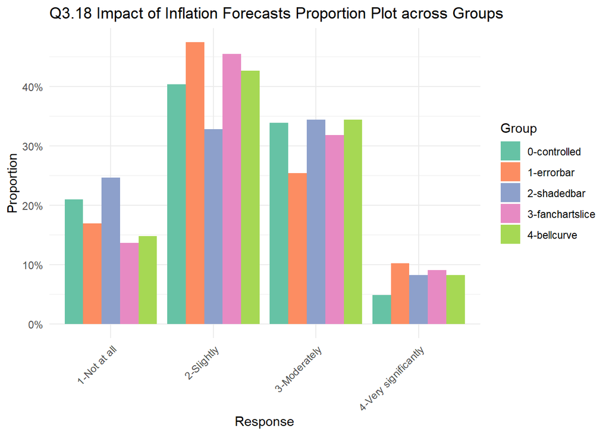

```r
q3_18_prop  <- as.data.frame(q3_18_contingency)
# rename columns
names(q3_18_prop) <- c("Q3.18", "Group", "Count")
# add a labelled column
q3_18_prop <- q3_18_prop %>%
  mutate(Q3.18_label = case_when(
    Q3.18 == "1" ~ "1-Not at all",
    Q3.18 == "2" ~ "2-Slightly",
    Q3.18 == "3" ~ "3-Moderately",
    Q3.18 == "4" ~ "4-Very significantly"
  ))
# calculate proportions within each group
q3_18_prop <- q3_18_prop %>%
  group_by(Group) %>%
  mutate(Proportion = Count / sum(Count))
ggplot(q3_18_prop, aes(x = as.factor(`Q3.18_label`), y = Proportion, fill = Group)) + geom_col(position = "dodge") +
  labs(
    title = "Q3.18 Impact of Inflation Forecasts Proportion Plot across Groups",
    x = "Response",
    y = "Proportion"
  ) +
   scale_fill_brewer(palette = "Set2")+
  scale_y_continuous(labels = scales::percent_format(accuracy = 1)) +
  theme_minimal()+
  theme(axis.text.x = element_text(angle = 45, hjust = 1))
```

Plot pie chart including all participants

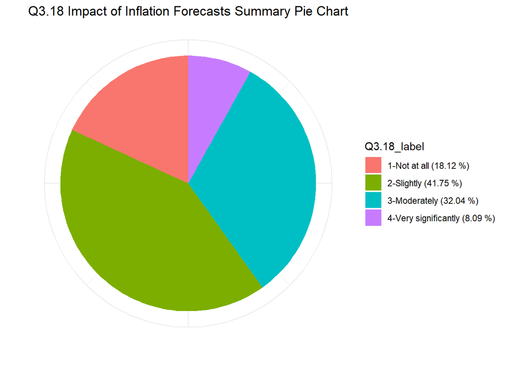

```r
q3_18_summary <- q3_18_prop %>%
  group_by(`Q3.18_label`) %>%
  summarise(total_count = sum(Count), .groups = "drop") %>%
  mutate(proportion = total_count / sum(total_count),
         `Q3.18_label` = paste0(`Q3.18_label`, " (", round(proportion * 100, 2), " %)"))
ggplot(q3_18_summary, aes(x = "",y = proportion, fill = `Q3.18_label`)) +
  geom_col(width = 1) +
  coord_polar(theta = "y") +
  labs(title = "Q3.18 Impact of Inflation Forecasts Summary Pie Chart",
       x = "",
       y = "") +
  theme_minimal() +
  theme(axis.text.x = element_blank())
```

## Q3.19 Response to Inflation Forecasts

How much do you adjust or take action in response to inflation forecasts (information about future inflation)?  
Variable: categorical  
Method: contingency table + chi-squared test  
**Result: Fail to reject the null hypothesis**

```r
# Initial Check
summary(as.numeric(rawdata_value$Q3.19))
```

```
##    Min. 1st Qu.  Median    Mean 3rd Qu.    Max.
##   1.000   2.000   2.000   2.236   3.000   4.000
```

```r
q3_19_table <- rawdata_value[, c("Q3.19", "group")]
q3_19_contingency <- table(q3_19_table$Q3.19, q3_19_table$group)
print(q3_19_contingency)
```

```
##
##     0-controlled 1-errorbar 2-shadedbar 3-fanchartslice 4-bellcurve
##   1           16         11          17              19          12
##   2           21         23          21              20          19
##   3           23         19          19              23          28
##   4            2          6           4               4           2
```

```r
# Chi-squared test
chisq.test(q3_19_contingency)
```

```
##
##  Pearson's Chi-squared test
##
## data:  q3_19_contingency
## X-squared = 8.7777, df = 12, p-value = 0.7218
```

Response to Inflation Forecasts proportion bar plot across different groups

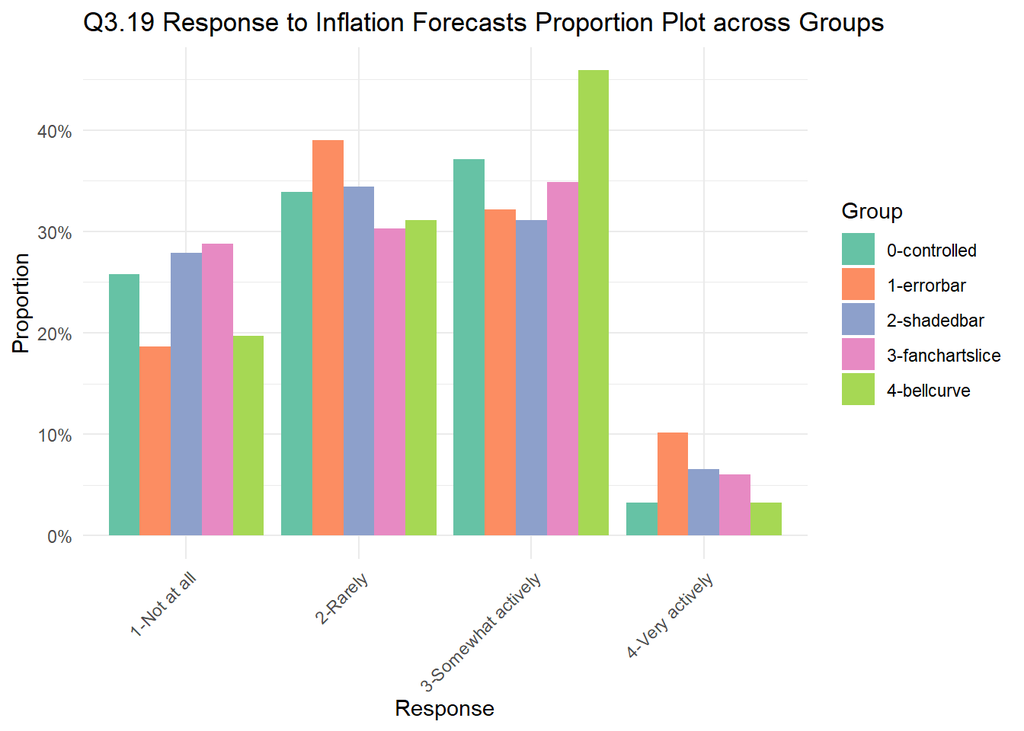

```r
q3_19_prop  <- as.data.frame(q3_19_contingency)
# rename columns
names(q3_19_prop) <- c("Q3.19", "Group", "Count")
# add a labelled column
q3_19_prop <- q3_19_prop %>%
  mutate(Q3.19_label = case_when(
    Q3.19 == "1" ~ "1-Not at all",
    Q3.19 == "2" ~ "2-Rarely",
    Q3.19 == "3" ~ "3-Somewhat actively",
    Q3.19 == "4" ~ "4-Very actively"
  ))
# calculate proportions within each group
q3_19_prop <- q3_19_prop %>%
  group_by(Group) %>%
  mutate(Proportion = Count / sum(Count))
ggplot(q3_19_prop, aes(x = as.factor(`Q3.19_label`), y = Proportion, fill = Group)) + geom_col(position = "dodge") +
  labs(
    title = "Q3.19 Response to Inflation Forecasts Proportion Plot across Groups",
    x = "Response",
    y = "Proportion"
  ) +
   scale_fill_brewer(palette = "Set2")+
  scale_y_continuous(labels = scales::percent_format(accuracy = 1)) +
  theme_minimal()+
  theme(axis.text.x = element_text(angle = 45, hjust = 1))
```

Plot pie chart including all participants

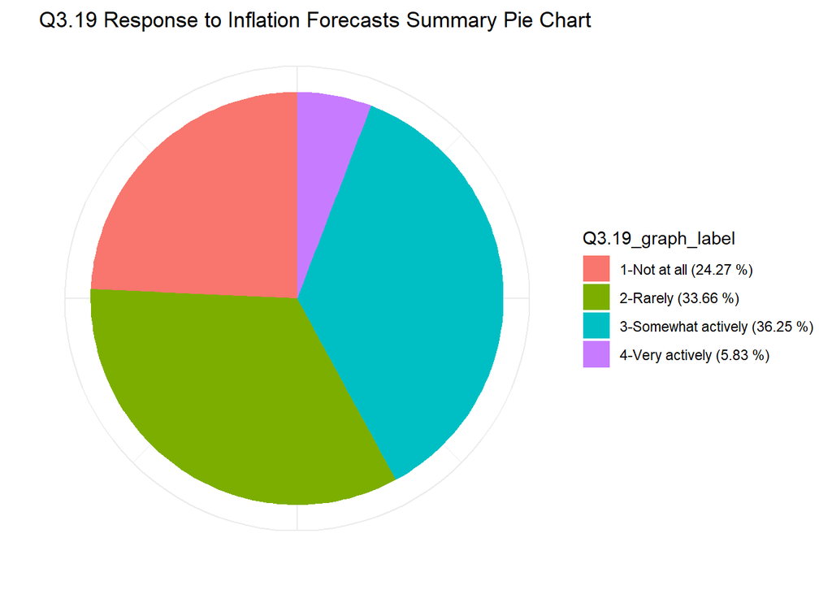

```r
q3_19_summary <- q3_19_prop %>%
  group_by(`Q3.19_label`) %>%
  summarise(total_count = sum(Count), .groups = "drop") %>%
  mutate(proportion = total_count / sum(total_count),
         `Q3.19_graph_label` = paste0(`Q3.19_label`, " (", round(proportion * 100, 2), " %)"))
ggplot(q3_19_summary, aes(x = "",y = proportion, fill = `Q3.19_graph_label`)) +
  geom_col(width = 1) +
  coord_polar(theta = "y") +
  labs(title = "Q3.19 Response to Inflation Forecasts Summary Pie Chart",
       x = "",
       y = "") +
  theme_minimal() +
  theme(axis.text.x = element_blank())
```